# DATA VISUALISATION PORTFOLIO

INTRODUCTION

DATA

DATA PREPROCESSING

TYPES OF VISUALISATIONS

CONCLUSION

BIBLIOGRAPHY

## INTRODUCTION

In a world filled with data, the ability to transform complex information into clear and engaging visuals is essential. One way to extract information from data is to visualize it in a way that conveys the desired messages accurately, without misleading like a scientist, and is aesthetically pleasing like a designer (Wilke, 2019). This visualization portfolio offers a collection of interesting visual stories derived from data that is raw. Beyond charts and graphs, each visualization exhibit insights, trends, and patterns essential for conveying message effectively to the indended audience. This portfolio offers a rich display of versatile and effective visualizations that highlight the impact of visual storytelling like geospacial, widgets, wordcloud, correlation pair plots, box plots, animating plots as well as line, bar and pie plots. I am planning to showcase multiple types of visualisations using five different datasets taken from multiple sources.

## DATA

Crimes dataset (Asaniczka, 2024) is a collection of official crime records reported in Los Angeles City from 2020-2023 publicly accessible via the Los Angeles City Open Data portal (Los Angeles - Open Data Portal, n.d.). The aim is to visualise data from multiple catagorical variables where no direct counts involved in the dataset which makes it complex to visualise it. (World Population by Country 2024 (LiVE), n.d.) found in kaggle (World Data Population, 2024) is used for exploring interactive geospacial animation, (Global Ecological Footprint 2023, 2024) dataset sorced from (Data and Methodology - Global Footprint Network, 2024) to plot geospatial as well as scatter pairplot to display correlation and emotion dataset from hugging face (Hugging Face, 2023) available through kaggle (Emotion Dataset for Emotion Recognition Tasks, 2021) to display interactive widgets and display word cloud. Lastly, I have taken the UK elections dataset of 2017 (General Election 2017, 2019) and 2019 (General Election 2019, 2020) which is concatenated to create a Sankey diagram displaying changes in voter proportion across different political parties over these years. This I am demostrating as an attempt in which I critically evaluate it for future work.

**Importing necessary libraries:**

```python
import numpy as np
import seaborn as sns
import matplotlib.pyplot as plt
import pandas as pd
import plotly.express as px
from ipywidgets import widgets # For widgets
from wordcloud import WordCloud # For wordcloud
from PIL import Image, ImageOps # For image displaying in wordcloud
import numpy as np
import nltk # For wordcloud
import string
nltk.download('stopwords')
import plotly.graph_objs as go # For Sankey diagram
from matplotlib.sankey import Sankey
import plotly.graph_objects as go
import warnings
import plotly.io as pio # To export the figure to .html
```

**Reading the .csv files to data frame object using pandas:**

```python
df_crime = pd.read_csv('/Users/ak/Desktop/Potfolio/Crime_Data_from_2020_to_Present 4.csv')
df_population = pd.read_csv('/Users/ak/Desktop/Potfolio/world_population_data.csv')
df_eco = pd.read_csv('/Users/ak/Desktop/Potfolio/GlobalEcologicalFootprint_2023.csv', encoding='latin')
df_emotions = pd.read_csv('/Users/ak/Desktop/Potfolio/emotion.csv')
df_2017 = pd.read_csv('/Users/ak/Desktop/Potfolio/HoC-GE2017-results-by-constituency.csv')
df_2019 = pd.read_csv('/Users/ak/Desktop/Potfolio/HoC-GE2019-results-by-constituency.csv')
```

## DATA PREPROCESSING

```python
##### CRIMES DATASET ######

# Removing Duplicates
duplicate_rows = df_crime.duplicated()

# Removing nulls
df_crime.isnull().sum()

# Deleting rows with null values in specific columns
df_crime.dropna(subset=['premise_code','premise_description','victim_sex','victim_descent'], inplace=True)

# Deleting unwanted columns from the dataframe
df_crime=df_crime.drop(['modus_operandi', 'crime_code_1','crime_code_2','crime_code_3','crime_code_4'], axis=1)

# Converting 'date_reported' column to datetime format
df_crime['date_reported'] = pd.to_datetime(df_crime['date_reported'], format='%d/%m/%Y')

# Converting date_occured to datetime (Pandas.to_Datetime — Pandas 2.2.2 Documentation, n.d.)
df_crime['date_occurred'] = pd.to_datetime(df_crime['date_occurred'], format='%d/%m/%Y %H:%M')

# Deleting observations in which the victim age is 0 and only keeping victim's sex male, female, or unknown
df_crime = df_crime[((df_crime['victim_age'] > 0) & (df_crime['victim_sex'] != '-') & (df_crime['victim_sex'] != 'H'))]

# Replace victim_sex values
df_crime['victim_sex'] = df_crime['victim_sex'].replace({'F': 'Female', 'M': 'Male', 'X': 'Unknown'})

# Extracting year and month from 'date_occurred' and keeping it in separate columns
df_crime.loc[:, 'year'] = df_crime['date_occurred'].dt.year
df_crime.loc[:, 'month'] = df_crime['date_occurred'].dt.month

# Categorising ages to different categories
df_crime.loc[df_crime['victim_age'] < 18, 'age_group'] = 'juvenile'
df_crime.loc[df_crime['victim_age'].between(18,39), 'age_group'] = 'young adult'
df_crime.loc[df_crime['victim_age'].between(40,59), 'age_group'] = 'adult'
df_crime.loc[df_crime['victim_age'] >=60, 'age_group'] = 'old'

####### Ecological Footprints Dataset ########

# Correcting the column names if necessary
df_eco.rename(columns={'Life Exectancy': 'Life Expectancy'}, inplace=True)

# Assuming your DataFrame is named df and the GDP per capita column is named 'gdp_per_capita'
df_eco['Per Capita GDP'] = df_eco['Per Capita GDP'].str.replace(r'[$,]', '', regex=True)

# Replace all whitespace with NaN (Replacing Blank Values (White Space) With NaN in Pandas, n.d.)
df_eco['Per Capita GDP'].replace(r'^\s*$', pd.NA, regex=True, inplace=True)
df_eco['Per Capita GDP'] = df_eco['Per Capita GDP'].fillna(0)

# Converting certain columns from object type to numeric
columns_to_convert = ['Total Ecological Footprint (Consumption)', 'HDI', 'SDGi', 'Per Capita GDP', 'Total biocapacity ', 'Population (millions)', 'Life Expectancy']

for column in columns_to_convert:
    df_eco[column] = pd.to_numeric(df_eco[column], errors='coerce')

####### Emotions Dataset ########

#Since in the source dataset it is given corresponding emotion of each label : sadness (0), joy (1), love (2), anger (3), fear (4).
dict_emotion = {0:"sad", 1:"happy", 2:"love", 3:"anger", 4:"fear"}
df_emotions['emotion'] = df_emotions['label'].map(dict_emotion)

# Filter out rows with NaN values in the 'emotion' column
df_emotions = df_emotions.dropna(subset=['emotion'])

###### UK Elections #######

# Define the common party columns
party_cols_2017 = ['Con', 'Lab', 'LD', 'Green', 'SNP', 'PC', 'DUP', 'SF', 'SDLP', 'UUP', 'APNI', 'UKIP']
party_cols_2019 = ['Con', 'Lab', 'LD', 'Green', 'SNP', 'PC', 'DUP', 'SF', 'SDLP', 'UUP', 'APNI', 'BRX']

# Function to convert columns to numeric, handling errors
def convert_to_numeric(df, columns):
    for column in columns:
        df[column] = pd.to_numeric(df[column], errors='coerce')
    return df

# Convert relevant columns to numeric
df_2017 = convert_to_numeric(df_2017, party_cols_2017)
df_2019 = convert_to_numeric(df_2019, party_cols_2019)
```

## TYPES OF VISUALISATIONS

1. Bar Plot
2. Box Plot
3. Line Plot
4. Pie Chart
5. Geospatial Plot
6. Pair Plot
7. Widgets
8. Word Cloud
9. Sankey Diagram

## Bar Plot

This analysis creates a bar plot using seaborn to visualize the number of crime reports filed, categorized by the age group and sex of the victims. The significance of this plot is to clearly depict data trends across different age categories and sex by using the hue parameter to differenciate between male, female, and unknown victims. The order parameter ensures the age groups 'juvenile(less than 18)', 'young adult(18-39)', 'adult(40-59)', and old(60 and above)' are displayed a meaningful sequence. Additionally, the palette parameter is used to assign different colours to the bars, enhancing visual catagorical differentiation and interpretability of the data. I have excluded victim sex that is 'unknown' as it is minority and cannot be depicted clearly in the visualisation. The colour aesthetics used differentiate the male and female genders.

Figure 1 illustrates that the targetted victims mostly fall within the age group young adults (20-39) and also female victims are more than male victims for juvenile and young adults.

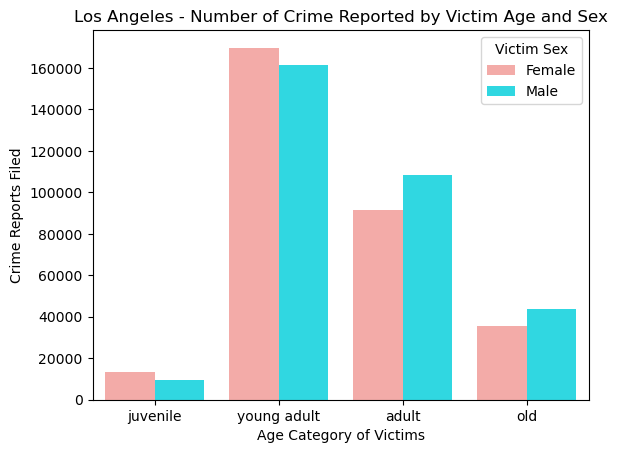

```python
# To plot in a particular order for catagorical variable
age_order = ['juvenile', 'young adult', 'adult', 'old']

# Excluding 'unknown' sex category as it is minority and cannot be clearly represented as compared to male and female
df_crime_updated = df_crime[df_crime['victim_sex'] != 'Unknown']

# Grouping the age and sex and counting the crimes count
age_sex_counts = df_crime_updated.groupby(['age_group', 'victim_sex']).size().reset_index(name='Count')

# Using bar plot to plot categorical variables and displayed in order (Seaborn.Barplot — Seaborn 0.13.2 Documentation, n.d.)
sns.barplot(data=age_sex_counts, x='age_group', y='Count', hue='victim_sex', palette=['#ff9f9b', '#12f1ff'], order=age_order)

plt.xlabel('Age Category of Victims')
plt.ylabel('Crime Reports Filed')
plt.title('Los Angeles - Number of Crime Reported by Victim Age and Sex')
plt.legend(title='Victim Sex')
plt.show()
```

##### Figure 1 : Crime reports filed, categorized by the age group and victim sex

## Box Plot

The box plot in Figure 3 illustrates the age distribution of female and male victims in Vandalism cases. The median age for females is around 40 and for males, it is slightly higher than 40. The interquartile range (IQR) for females ranges from 30 to 50, whereas for males, it ranges from 30 to 55. Both categories display whiskers beyond the IQR, representing a wider age range. Outliers are present above the age of 80 for both sexes, highlighting occasional instances of much older victims. This plot shows that vandalism affects a wide age range with similar distributions for both genders. The color used clearly distinguishes the genders.

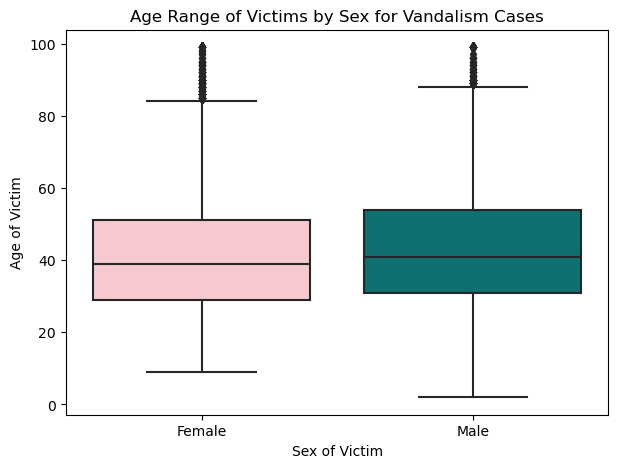

```python
# Filtering for crime description containing the text "vandalism"
df_vandalism = df_crime_updated[df_crime_updated['crime_description'].str.contains('VANDALISM')]

# Creating a box plot
plt.figure(figsize=(7, 5))
sns.boxplot(data=df_vandalism, x='victim_sex', y='victim_age', palette=['pink', 'teal'])
plt.xlabel('Sex of Victim')
plt.ylabel('Age of Victim')
plt.title('Age Range of Victims by Sex for Vandalism Cases')
plt.show()
```

##### Figure 3 : Age range of victims by sex for Vandalism cases

## Line Plot

Figure 4 shows the number of crimes categorized into part 1, which includes serious offenses such as homicide, rape, robbery, burglary, etc., and part 2, which includes crimes like vandalism, gambling, etc (Offense Definitions, 2019) over the years from 2020 to 2023. While part 1 crimes were consistently higher than part 2 crimes, there was an unexpected increase in part 2 crimes in 2022. As a result, the number of part 2 crimes almost reached the level of part 1 crimes, which was the highest in all of these years. For this I have used the line plot of the Seaborn library using markers, linestyles and palettes as parameters to better visualise the trend.

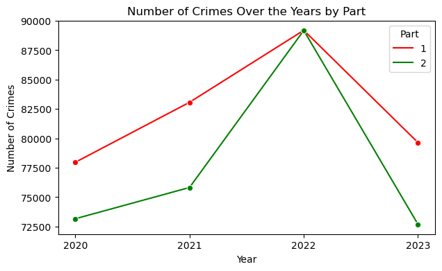

```python
# Ignoring the future warnings (How to Suppress Pandas Future Warning?, n.d.)
warnings.simplefilter(action='ignore', category=FutureWarning)

# Grouping by 'year' and 'part', then counting the crimes
df_grouped_part = df_crime.groupby(['year', 'part']).size().reset_index(name='crime_count')

# Plotting the data
plt.figure(figsize=(7, 4))
sns.lineplot(data=df_grouped_part, x='year', y='crime_count', hue='part', marker='o', linestyle='-',palette=['red', 'green'])

# Showing the plot
plt.xlabel('Year')
plt.ylabel('Number of Crimes')
plt.title('Number of Crimes Over the Years by Part')
plt.gca().set_xticks(df_crime["year"].unique()) #(X Axis Gets Transformed to Floats, n.d.)
plt.legend(loc='upper right', title='Part', bbox_to_anchor=(1.0, 1))
plt.show()
```

##### Figure 4: Number of crimes over the years based on part 1 and 2 crimes

## Pie Chart

From a general audience perspective, top 10 crimes of Los Angeles can be displayed in a Pie chart providing the proportion of each crimes without much technicality or distractions. I have used autopct argument to display the percentages with 2 digits after the decimal point shown in Figure 5

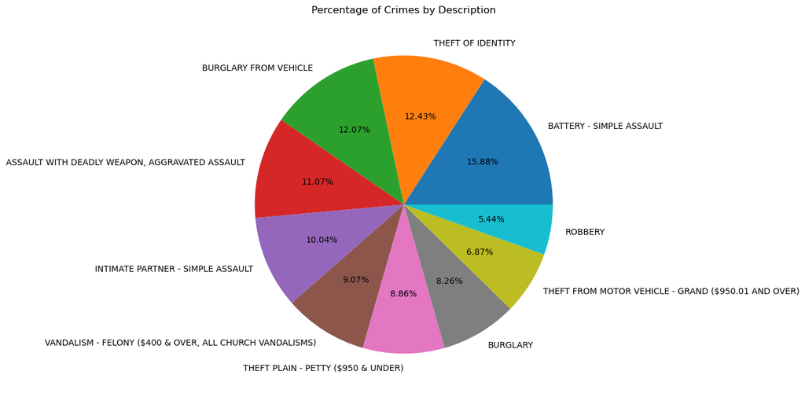

```python
#Calculate frequency of each crime and sort desc to find the top 10
crime_code_counts = df_crime_updated['crime_code'].value_counts()
sorted_crime_codes = crime_code_counts.index.tolist()
top_10_crime_codes = sorted_crime_codes[:10]
top_10_crimes_df = df_crime_updated[df_crime_updated['crime_code'].isin(top_10_crime_codes)]

# Calculate the frequency of each crime description
crime_description_counts = top_10_crimes_df['crime_description'].value_counts()

# Create a pie chart
plt.figure(figsize=(8, 8))
plt.pie(crime_description_counts, labels=crime_description_counts.index, autopct='%.2f%%')
plt.title('Percentage of Crimes by Description')
plt.show()
```

##### Figure 5: Piechart displaying the proportion of top 10 crimes

## Geospatial Plot

In this section I have displayed 3 different types of geospacial plots using 3 different datasets. This analysis shows the number of crimes occurred in different areas of LA using scatter_mapbox function of Ploty Express where suitable color scale and sizing is given to highlight the range.For the layout, I have used open-street-map. In Figure 6 it is evident that highest and lowest crimes has taken place in Central and Foothill respectively given in same colour.

```python
# Create the scatter plot on Mapbox

# First we need to count the number of crimes that occurred per area
crime_counts_per_area = df_crime.groupby('area_name').agg(
    crime_count=('area_name', 'size'),
    latitude=('latitude', 'mean'),
    longitude=('longitude', 'mean')
).reset_index()

# To differentiate between the sizes of the plots (Normalize a Column to Represent It as a Size in a Scatter Plot, n.d.)
crime_counts_per_area['size_normalized'] = crime_counts_per_area['crime_count']**3.10

# Plotting mapbox with scatter bubble
fig = px.scatter_mapbox(crime_counts_per_area,
                        lat='latitude',
                        lon='longitude',
                        size='size_normalized',
                        color='crime_count',
                        hover_name='area_name',
                        hover_data={"latitude": True, "longitude": True, "crime_count": True, "size_normalized": False},
                        center={'lat': 34.052235, 'lon': -118.243683},
                        title="Map displaying Area Based Crimes Reported in Los Angeles",
                        color_continuous_scale=px.colors.cyclical.IceFire,
                        zoom=8,
                        size_max=40)

# Show the plot
fig.update_layout(mapbox_style='open-street-map')
fig.show()
```

[interactive chart not shown]

##### Figure 6: Crimes reported in different areas using Map box

For the next visualisation, I have taken the world population dataset that has data ranging from 1970 to 2023 in certain intervals to show the transition of increase/decrease in population around the world using choropleth function. To convert it to a form suitable for geospacial plotting, I need to rename my column to include only the year and remove the word "population" and also reshape the dataset from wide to long format so that each row represents an observation of a single variable. From the figure it is clear that India has increased its population drastically and crossed China that remained steady for these 5 decades. The colours don't show much differences as the change is too small that it is unnoticeable as in Figure 7.

```python
# Reshaping the renaming the data from wide to long format (pandas.DataFrame.melt — Pandas 2.2.2 Documentation, n.d.)
columns_renamed = {
    '2023 population': '2023',
    '2022 population': '2022',
    '2020 population': '2020',
    '2015 population': '2015',
    '2010 population': '2010',
    '2000 population': '2000',
    '1990 population': '1990',
    '1980 population': '1980',
    '1970 population': '1970'
}

data_renamed = df_population.rename(columns=columns_renamed)

long_data = data_renamed.melt(
    id_vars=['rank', 'cca3', 'country', 'continent', 'area (km²)', 'density (km²)', 'growth rate', 'world percentage'],
    var_name='year',
    value_name='population'
)

# Converting the year to integer type
long_data['year'] = long_data['year'].astype(str)
long_data = long_data.sort_values(['year'])

# Creating the animated map using choropleth
fig = px.choropleth(long_data,
                    locations="cca3",
                    color="population",
                    hover_name="country",
                    animation_frame="year",
                    projection="natural earth",
                    color_continuous_scale=px.colors.sequential.Turbo,
                    title="World Population Over Time")

fig.update_layout(coloraxis_colorbar=dict(title='Population'))
```

[interactive chart not shown]

##### Figure 7: Animated geospatial plot for world population

Figure 8 shows a scatter geo plot that visually represents countries categorized by regions and sized by Per Capita GDP using a natural earth projection. Each region is color-coded and larger circles indicate higher Per Capita GDP with noticeable clusters of large circles in North America, the EU-27, and parts of Asia-Pacific, reflecting higher wealth. Conversely, Africa and some regions in Asia and South America show smaller circles, indicating lower economic levels. This plot effectively highlights global economic disparities across different regions.

```python
fig = px.scatter_geo(df_eco,
                     locations='Country',
                     locationmode='country names',  # Interpreting 'locations' as country names
                     color='Region',
                     size='Per Capita GDP',
                     hover_name='Country',
                     projection='natural earth',
                     title="Per Capita GDP across Regions")

fig.show()
```

[interactive chart not shown]

##### Figure 8: Scatter geoplot of Per Capita GDP across regions

## Pair Plot

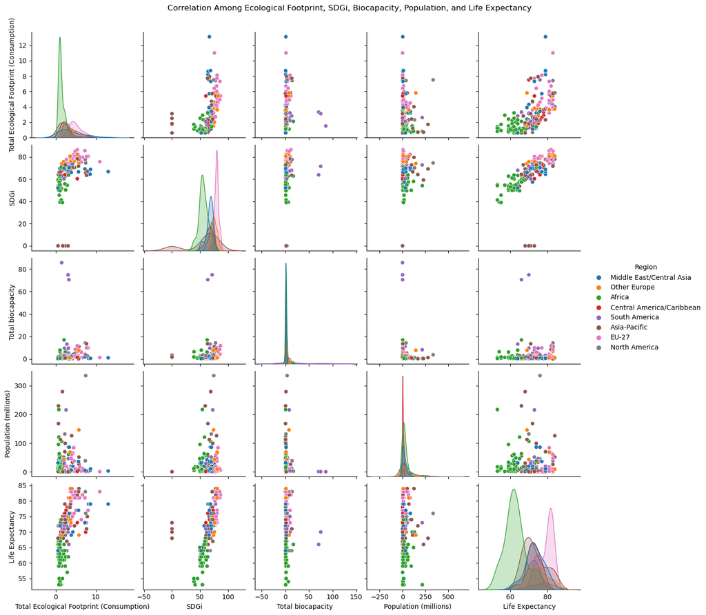

```python
# Selecting relevant columns for the pairplot
columns_needed = ['Total Ecological Footprint (Consumption)', 'SDGi', 'Total biocapacity ', 'Population (millions)', 'Life Expectancy']

# Creating the pairplot
pairplot = sns.pairplot(df_eco, vars = df_eco[columns_needed], hue ="Region")
pairplot.fig.suptitle('Correlation Among Ecological Footprint, SDGi, Biocapacity, Population, and Life Expectancy', y=1.03)  # Adjust title position
plt.show()
```

##### Figure 9: Correlation among Ecological Footprint, Sustainability, Biocapacity, Population, and Life Expectancy

## Widgets

For the next 2 sections, I have taken emotion datasets taken from hugging face (Dair-ai/Emotion · Datasets at Hugging Face, 2023) available through kaggle (Emotion Dataset for Emotion Recognition Tasks, 2021) to display interactive widgets and display word cloud.

```python
##### Preprocessing #####

# Adding certain set of words to stopwords that has many occurrences and are generic
custom_stopwords = set(nltk.corpus.stopwords.words('english')).union({
    'feel', 'feeling', 'like', 'im', 'ive', 'would', 'still', 'want', 'really', 'get', 'got', 'people', 'know', 'time', 'one', 'little','think','things', 'even', 'bit', 'make', 'could'
})

# Preprocessing function
def clean_text(textin):
    tr = str.maketrans('', '', string.punctuation)
    text = textin.translate(tr)
    text = text.lower()
    text = nltk.word_tokenize(text)
    stopwords = custom_stopwords
    text = [word for word in text if word not in stopwords and len(word) > 1]
    return text


# Function to display top 10 words based on its occurrence per each emotion
def plot_top_10_words(emotion):
    df_filtered = df_emotions[df_emotions['emotion'] == emotion] #Filtering the emotions

    # Preprocessing and tokenizing
    all_words = []
    for text in df_filtered['text']:
        all_words.extend(clean_text(text))

    # Creating a DataFrame for the words
    df_words = pd.DataFrame(all_words, columns=['words'])

    # For getting the value counts
    counts = df_words['words'].value_counts()

    # Get top 10 words and sort for plotting
    countsT = counts[:10].sort_values()

    # Plotting
    plt.figure(figsize=(10, 5))
    plt.barh(countsT.index, countsT)
    plt.xlabel('Count')
    plt.ylabel('Top 10 words')
    plt.title(f'Top 10 Words for {emotion.capitalize()}')
    plt.show()
```

```python
##### Making the widgets work #####

# Creating a dropdown widget
emotion_widget = widgets.Dropdown(
    description='Select:',
    options=df_emotions['emotion'].unique(),
    value=df_emotions['emotion'].unique()[0]  # Set the default value to the first option
)


# Creating a function to update the plot based on dropdown selection. Wait is set as True which avoids a sudden blinking as the state changes
def response(change):
    with change_state:
        change_state.clear_output(wait=True)
        plot_top_10_words(emotion_widget.value)

# Create an output widget
change_state = widgets.Output()


# Attaching the function to the widget
emotion_widget.observe(response, names='value')

# Displaying the widget
display(widgets.VBox([emotion_widget, change_state]))

# To show the default plot as plot of first dropdown value
with change_state:
    plot_top_10_words(emotion_widget.value)
```

```
VBox(children=(Dropdown(description='Select:', options=('sad', 'anger', 'love', 'fear', 'happy'), value='sad')…
```

## Word Cloud

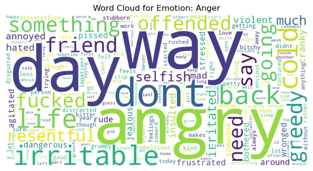

```python
# Filter the DataFrame for the emotion 'happy'
df_anger = df_emotions[df_emotions['emotion'] == 'anger']

# Preprocess and tokenize the text data for 'happy' emotion
all_words_anger = []
for text in df_anger['text']:
    all_words_anger.extend(clean_text(text))

# Generate the word cloud
wordcloud = WordCloud(width=800, height=400, background_color='white').generate(' '.join(all_words_anger))

# Display the word cloud
plt.figure(figsize=(9, 4))
plt.imshow(wordcloud, interpolation='bilinear')
plt.axis('off')
plt.title('Word Cloud for Emotion: Anger')
plt.show()
```

##### Figure 11: Word Cloud of angry emotion

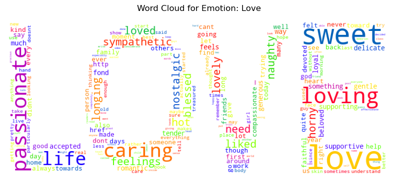

```python
# Filtering the DataFrame for the emotion 'happy'
df_love = df_emotions[df_emotions['emotion'] == 'love']

# Preprocessing and tokenizing the text data for 'happy' emotion
all_words_love = []
for text in df_love['text']:
    all_words_love.extend(clean_text(text))

# Creating a DataFrame for the words
df_words = pd.DataFrame(all_words_love, columns=['words'])
counts = df_words['words'].value_counts() # Get the value counts

# Creating a dictionary of these words
topwords = counts[counts>3].to_dict()

# Reading the mask image
im = Image.open('/Users/ak/Desktop/Potfolio/love_text.jpeg')
ima = np.array(im)

# Generating the word cloud
wordcloud = WordCloud(width=900, height=800, background_color='white',contour_color='black', colormap='prism_r', mask=ima).generate_from_frequencies(topwords)

# Displaying
plt.figure(figsize=(10, 5))
plt.imshow(wordcloud)
plt.axis('off')
plt.title('Word Cloud for Emotion: Love')
plt.show()
```

##### Figure 12: Word Cloud inside a picture

## Sankey Diagram

I decided to do a Sankey diagram for the UK Elections 2017 and 2019 (House of Commons Library, 2023). The Sankey diagrams effectively visualize the stability and shifts in political dominance across constituencies in the UK from 2017 to 2019. While some regions like Wales and Northern Ireland showed considerable consistency in party dominance, others like Scotland and England exhibited more dynamic changes, reflecting the evolving political landscape during this period (Figure 13. Nodes, links, values and labels are specified based on the required flow with keeping the grouped count data as transition count with suitable palettes. As future work, it could be further improved by specifying more clearer transition as in the case England.

```python
##### Preprocessing and Merging dataframes data_2017 and data_2019 to one #####

# Adjusting the function to find the winning party for each row
def get_winning_party(row, party_columns):
    votes = row[party_columns].fillna(0).astype(float)  # Fill NaNs with 0 and convert to float
    max_votes = votes.max()
    winning_party = votes.idxmax()
    return winning_party

# Find the winning party for each row in both datasets (pandas.DataFrame.apply — Pandas 2.2.2 Documentation, n.d.)
df_2017['Winning Party'] = df_2017.apply(lambda row: get_winning_party(row, party_cols_2017), axis=1)
df_2019['Winning Party'] = df_2019.apply(lambda row: get_winning_party(row, party_cols_2019), axis=1)

# Creating a DF with constituency names and winning parties for both years
constituency_col = 'Constituency name'
results_2017 = df_2017[[constituency_col, 'Winning Party']]
results_2019 = df_2019[[constituency_col, 'Winning Party']]

# Renaming columns
results_2017.columns = [constituency_col, 'Winning Party 2017']
results_2019.columns = [constituency_col, 'Winning Party 2019']

# Merge the results on constituency name
merged_results = pd.merge(results_2017, results_2019, on=constituency_col)

# Add country information to the merged results
data_2017_with_country = df_2017[[constituency_col, 'Country name']].drop_duplicates()
merged_results_with_country = pd.merge(merged_results, data_2017_with_country, on=constituency_col)
```

```python
##### PLOTTING THE SANGEY DIAGRAM FOR EACH COUNTRY #####


# The coding part is mostly done referring to the tutorial done by Solanki (2022)

def create_sankey_for_country(country_data, country_name):
    # Creating a list of unique parties
    parties_2017 = country_data['Winning Party 2017'].unique().tolist()
    parties_2019 = country_data['Winning Party 2019'].unique().tolist()

    # Combining each party from 2017 and 2019
    all_parties = list(set(parties_2017 + parties_2019))

    # Creating mappings for the parties
    party_indices_2017 = {party: index for index, party in enumerate(parties_2017)}
    party_indices_2019 = {party: index + len(parties_2017) for index, party in enumerate(parties_2019)}

    # Generating index lists of source nodes and target nodes with counts
    transitions = country_data.groupby(['Winning Party 2017', 'Winning Party 2019']).size().reset_index(name='count')

    source_indices = [party_indices_2017[party] for party in transitions['Winning Party 2017']]
    target_indices = [party_indices_2019[party] for party in transitions['Winning Party 2019']]
    values = transitions['count'].tolist()  # Use the counts as values

    colors = px.colors.qualitative.D3  # Color Palette
    node_colors_mappings = {node: np.random.choice(colors) for node in all_parties}  # Node to Color Mapping

    # Creating the node labels to be given in both source and target
    labels = [f'{party} 2017' for party in parties_2017] + [f'{party} 2019' for party in parties_2019]

    # Node and link colors
    node_colors = [node_colors_mappings[node] for node in parties_2017 + parties_2019]
    link_colors = [node_colors_mappings[party] for party in transitions['Winning Party 2017']]

    # Create the Sankey diagram
    fig = go.Figure(data=[go.Sankey(
        node=dict(
            pad=15,
            thickness=20,
            line=dict(color="black", width=0.5),
            label=labels,
            color=node_colors
        ),
        link=dict(
            source=source_indices,
            target=target_indices,
            value=values,
            color=link_colors,
            hovertemplate='Source: %{source.label}<br>Target: %{target.label}<br>Value: %{value}<extra></extra>'
        )
    )])

    fig.update_layout(
        title_text=f"Changes in Winning Parties from 2017 to 2019 - {country_name}",
        font_size=10,
        title_x=0.5,
        plot_bgcolor='white'
    )

    fig.show()

# Display Sankey diagrams looping each country
countries = merged_results_with_country['Country name'].unique()
for country in countries:
    country_data = merged_results_with_country[merged_results_with_country['Country name'] == country]
    if not country_data.empty:
        create_sankey_for_country(country_data, country)
    else:
        print(f"No data available for {country}")
```

[interactive chart not shown]

##### Figure 13: Sankey diagram for winning teams (2017 and 2019)

### CONCLUSION

My data visualization portfolio demonstrates the ability to interpret and present complex datasets using various plotting techniques of matplotlib and seaborn. Key insights include the predominance of young adult victims in crime reports and the similar age distributions in vandalism cases for both genders. Trends in serious and lesser offenses over recent years are highlighted, along with the geographical distribution of crimes in LA. Global population growth and economic aspects are effectively visualized using animated and scatter geo plots. Interactive widgets and word clouds enhance user engagement by showcasing frequent words associated with emotions. Lastly, the Sankey diagram illustrates political shifts in the UK between 2017 and 2019. Each visualization provides clear, actionable insights, ensuring complex data is interpretable.

### BIBLIOGRAPHY

Wilke, C. O. (2019). Fundamentals of Data Visualization. Claus O. Wilke. https://clauswilke.com/dataviz/introduction.html

Asaniczka. (2024, February 17). Los Angeles Crime Data 2020-2023. Kaggle. https://www.kaggle.com/datasets/asaniczka/crimes-in-los-angeles-2020-2023/data

Datala: Information, insights, and analysis from the City of Angels: Los Angeles - open data portal. City of Los Angeles. (n.d.). https://data.lacity.org/

Offense definitions. (n.d.). FBI. https://ucr.fbi.gov/crime-in-the-u.s/2011/crime-in-the-u.s.-2011/offense-definitions

General Election 2019: full results and analysis. (2020, January 28). UK Parliament. https://commonslibrary.parliament.uk/research-briefings/cbp-8749/

General Election 2017: full results and analysis. (2019, January 29). UK Parliament. https://commonslibrary.parliament.uk/research-briefings/cbp-7979/

Global Ecological Footprint 2023🌐[latest report]. (2024, May 17). Kaggle. https://www.kaggle.com/datasets/jainaru/global-ecological-footprint-2023/data

Data and Methodology - Global Footprint Network. (2024, February 16). Global Footprint Network. https://www.footprintnetwork.org/resources/data/

dair-ai/emotion · Datasets at Hugging Face. (2023, March 22). https://huggingface.co/datasets/dair-ai/emotion

Emotion Dataset for emotion recognition tasks. (2021, September 15). Kaggle. https://www.kaggle.com/datasets/parulpandey/emotion-dataset?select=training.csv

pandas.to_datetime — pandas 2.2.2 documentation. (n.d.). https://pandas.pydata.org/docs/reference/api/pandas.to_datetime.html

House of Commons Library. (2023, March 24). Pensioner poverty. Commons Library Research Briefing. https://commonslibrary.parliament.uk/research-briefings/cbp-8749/

Decoding UK elections with interactive visualizations. (2024, January 16). Flourish. https://flourish.studio/blog/visualizing-uk-elections/

seaborn.barplot — seaborn 0.13.2 documentation. (n.d.). https://seaborn.pydata.org/generated/seaborn.barplot.html

pandas.DataFrame.melt — pandas 2.2.2 documentation. (n.d.). https://pandas.pydata.org/pandas-docs/stable/reference/api/pandas.DataFrame.melt.html

World Population by Country 2024 (LiVE). (n.d.). https://worldpopulationreview.com/

World data population. (2024, January 12). Kaggle. https://www.kaggle.com/datasets/tanishqdublish/world-data-population/data

How to suppress Pandas Future warning? (n.d.). Stack Overflow. https://stackoverflow.com/questions/15777951/how-to-suppress-pandas-future-warning

Offense Definitions. (2019). https://ucr.fbi.gov/crime-in-the-u.s/2019/crime-in-the-u.s.-2019/topic-pages/offense-definitions

x axis gets transformed to floats. (n.d.). Stack Overflow. https://stackoverflow.com/questions/48715330/x-axis-gets-transformed-to-floats

normalize a column to represent it as a size in a scatter plot. (n.d.). Stack Overflow. https://stackoverflow.com/questions/50310059/normalize-a-column-to-represent-it-as-a-size-in-a-scatter-plot

Solanki, S. (2022, August 1). How to Create Sankey Diagrams (Alluvial) in Python (holoviews & plotly)? https://coderzcolumn.com/tutorials/data-science/how-to-plot-sankey-diagram-in-python-jupyter-notebook-holoviews-and-plotly?source=post_page-----4b7a7841f050--------------------------------

pandas.DataFrame.apply — pandas 2.2.2 documentation. (n.d.). https://pandas.pydata.org/docs/reference/api/pandas.DataFrame.apply.html